# ATAC_06 - Performing HOMER motif enrichment on nucleosome-free regions from each sample group

Emma Bell

2020-05-01

# Summary

- Aim: To perform HOMER motif enrichment on nucleosome-free regions from each sample group.
- Objectives:
  1. To create subsets if nucleosome-free regions unique to each sample group;
  2. To perform HOMER motif enrichment on the nucleosome-free regions from and unique to each sample group;
  3. To visualise the results of the HOMER motif enrichment analysis.

## Configuration

This analysis requires the following packages:

```r
library(readxl)
library(vtree)
library(BiocParallel)
library(GenomicRanges)
library(writexl)
```

I use the `BiocParallel` package to parallelise R with the following parameters:

```r
param <- MulticoreParam(workers = 10, progressbar = TRUE)
```

This analysis requires the following R configuration object:

```r
r.config <- readRDS(file = file.path("code","r_config.RDS"))
```

## Metadata

```r
metadata <- read_excel(path = file.path(r.config$dirs$data.dir, "metadata.xlsx"), sheet = "ATAC")
metadata
```

| File | Donor | Stimulated | DAC |
| --- | --- | --- | --- |
| Donor61_unstimulated_untreated.narrowPeak | 61 | Unstimulated | Untreated |
| Donor61_stimulated_untreated.narrowPeak | 61 | Stimulated | Untreated |
| Donor61_stimulated_treated.narrowPeak | 61 | Stimulated | Treated |
| Donor70_unstimulated_untreated.narrowPeak | 70 | Unstimulated | Untreated |
| Donor70_stimulated_untreated.narrowPeak | 70 | Stimulated | Untreated |
| Donor70_stimulated_treated.narrowPeak | 70 | Stimulated | Treated |
| Donor71_unstimulated_untreated.narrowPeak | 71 | Unstimulated | Untreated |
| Donor71_stimulated_untreated.narrowPeak | 71 | Stimulated | Untreated |
| Donor71_stimulated_treated.narrowPeak | 71 | Stimulated | Treated |

I’ll use the `vtree` package to visualise the experimental design.

```r
vtree(z = metadata, vars = c("Stimulated","DAC"))
```

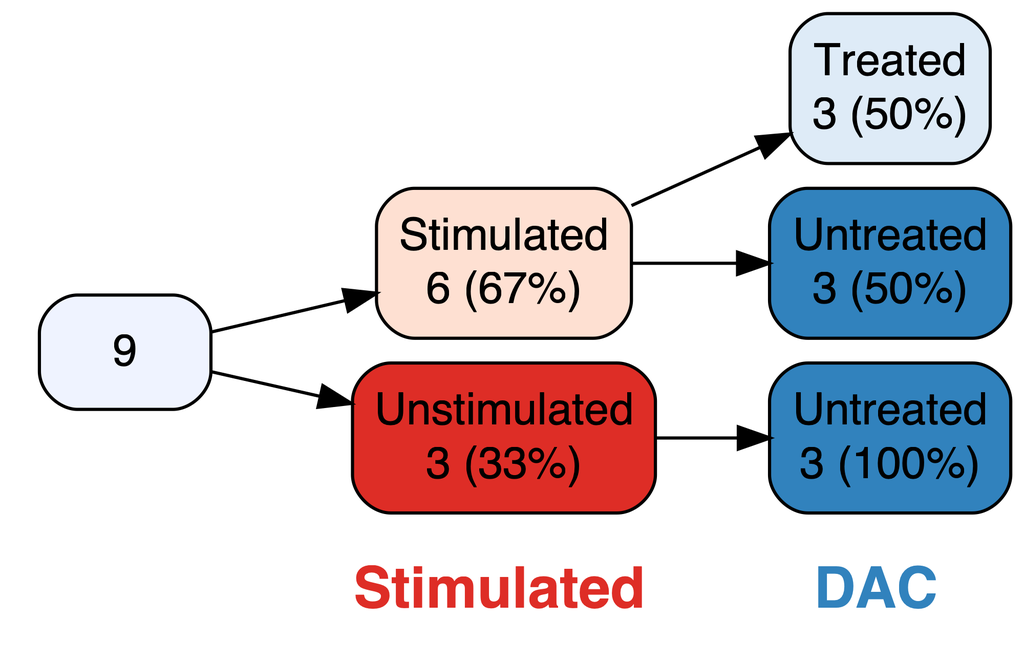

# Analysis

## 1. Creating subsets if nucleosome-free regions unique to each sample group

I’ll perform HOMER motif enrichment analysis comparing the nucleosome-free regions unique to stimulated and DAC treated and the stimulated and untreated sample groups against background of all peaks within the library.

To do this, I’ll first output bed files containing these subsets of peaks.

```bash
mkdir data/03_augmented/04_atac_homer
```

```r
atac.group <- readRDS(file = file.path(r.config$dirs$augmented.data.dir,"03_atac_nfrs","atac_nfrs_byGroup.RDS"))
```

```r
overlaps <- findOverlaps(query = atac.group[[2]], subject = atac.group[[3]])
stim.unique <- atac.group[[2]][-queryHits(overlaps)]
dac.unique <- atac.group[[3]][-subjectHits(overlaps)]

overlaps2 <- findOverlaps(query = dac.unique, subject = atac.group[[1]])
dac.unique <- dac.unique[-queryHits(overlaps2)]

overlaps3 <- findOverlaps(query = stim.unique, subject = atac.group[[1]])
stim.unique <- stim.unique[-queryHits(overlaps3)]

unique.nfrs <- list(stim.unique,dac.unique)
names(unique.nfrs) <- c("stim_unique","dac_unique")
for(i in 1:length(unique.nfrs)){
  this.group <- unique.nfrs[[i]]
  this.group.name <- names(unique.nfrs)[i]
  this.bed <- data.frame(chr = seqnames(this.group), start = start(this.group), end = end(this.group), id = paste("uid", 1:length(this.group), sep = "_"), blank = "", strand = "*")
  write.to <- file.path(r.config$dirs$augmented.data.dir,"04_atac_homer",paste0(this.group.name,".bed"))
  write.table(x = this.bed, file = write.to, sep = "\t", row.names = FALSE, col.names = FALSE, quote = FALSE)
}
```

I’ll also do this against the entire library.

```r
all.peaks <- c(atac.group[[1]],atac.group[[2]],atac.group[[3]])
lib.df <- data.frame(chr = seqnames(all.peaks), start = start(all.peaks), end = end(all.peaks), id = paste("uid", 1:length(all.peaks), sep = "_"), blank = "", strand = "*")
write.table(x = lib.df, file = file.path(r.config$dirs$augmented.data.dir,"04_atac_homer","atac_library.bed"), sep = "\t", row.names = FALSE, col.names = FALSE, quote = FALSE)
```

## 2. HOMER motif enrichment on the nucleosome-free regions from and unique to each sample group

I’ll make these comparisons:

- Stimulated (unique) vs All
- Stimulated + DAC (unique) vs All

```bash
findMotifsGenome.pl data/03_augmented/04_atac_homer/stim_unique.bed hg19 data/03_augmented/04_atac_homer/01_stimVsAll -nomotif -size given -p 10 -bg data/03_augmented/04_atac_homer/atac_library.bed
findMotifsGenome.pl data/03_augmented/04_atac_homer/dac_unique.bed hg19 data/03_augmented/04_atac_homer/02_dacVsAll -nomotif -size given -p 10 -bg data/03_augmented/04_atac_homer/atac_library.bed
```

## 3. Visualising the results of the HOMER motif enrichment analysis

```r
comparisons <- c("01_stimVsAll","02_dacVsAll")
homer <- lapply(X = comparisons, FUN = function(X){
  this.comparison <- X
  read.table(file = file.path(r.config$dirs$augmented.data.dir,"04_atac_homer",this.comparison,"knownResults.txt"), header = FALSE, sep = "\t", skip = 1, col.names = c("Motif","Consensus","P-value","Log P-value","q-value","N FG","PC FG","N BG","PC BG"), stringsAsFactors = FALSE)
})
names(homer) <- comparisons
```

```r
head(homer[[1]])
```

|  | Motif | Consensus | P.value | Log.P.value | q.value | N.FG | PC.FG | N.BG | PC.BG |
| --- | --- | --- | --- | --- | --- | --- | --- | --- | --- |
| 1 | FOXA1:AR(Forkhead,NR)/LNCAP-AR-ChIP-Seq(GSE27824)/Homer | AGTAAACAAAAAAGAACAND | 1 | -2.0870 | 1 | 12 | 0.48% | 80.2 | 0.33% |
| 2 | OCT4-SOX2-TCF-NANOG(POU,Homeobox,HMG)/mES-Oct4-ChIP-Seq(GSE11431)/Homer | ATTTGCATAACAATG | 1 | -1.9070 | 1 | 28 | 1.13% | 221.9 | 0.92% |
| 3 | Unknown-ESC-element(?)/mES-Nanog-ChIP-Seq(GSE11724)/Homer | CACAGCAGGGGG | 1 | -1.5040 | 1 | 424 | 17.12% | 4010.3 | 16.54% |
| 4 | Brn2(POU,Homeobox)/NPC-Brn2-ChIP-Seq(GSE35496)/Homer | ATGAATATTC | 1 | -1.4170 | 1 | 17 | 0.69% | 137.4 | 0.57% |
| 5 | RARg(NR)/ES-RARg-ChIP-Seq(GSE30538)/Homer | AGGTCAAGGTCA | 1 | -1.0680 | 1 | 10 | 0.40% | 83.6 | 0.34% |
| 6 | NFAT:AP1(RHD,bZIP)/Jurkat-NFATC1-ChIP-Seq(Jolma_et_al.)/Homer | SARTGGAAAAWRTGAGTCAB | 1 | -0.9355 | 1 | 40 | 1.62% | 372.8 | 1.54% |

```r
head(homer[[2]])
```

|  | Motif | Consensus | P.value | Log.P.value | q.value | N.FG | PC.FG | N.BG | PC.BG |
| --- | --- | --- | --- | --- | --- | --- | --- | --- | --- |
| 1 | Atf3(bZIP)/GBM-ATF3-ChIP-Seq(GSE33912)/Homer | DATGASTCATHN | 1e-04 | -9.354 | 0.0371 | 123 | 16.69% | 2886.5 | 11.93% |
| 2 | Fra1(bZIP)/BT549-Fra1-ChIP-Seq(GSE46166)/Homer | NNATGASTCATH | 1e-04 | -9.301 | 0.0371 | 110 | 14.93% | 2523.3 | 10.43% |
| 3 | AP-1(bZIP)/ThioMac-PU.1-ChIP-Seq(GSE21512)/Homer | VTGACTCATC | 1e-04 | -9.223 | 0.0371 | 132 | 17.91% | 3152.4 | 13.03% |
| 4 | JunB(bZIP)/DendriticCells-Junb-ChIP-Seq(GSE36099)/Homer | RATGASTCAT | 1e-03 | -8.610 | 0.0371 | 110 | 14.93% | 2569.7 | 10.62% |
| 5 | EKLF(Zf)/Erythrocyte-Klf1-ChIP-Seq(GSE20478)/Homer | NWGGGTGTGGCY | 1e-03 | -8.035 | 0.0371 | 90 | 12.21% | 2047.5 | 8.46% |
| 6 | RUNX(Runt)/HPC7-Runx1-ChIP-Seq(GSE22178)/Homer | SAAACCACAG | 1e-03 | -7.568 | 0.0371 | 220 | 29.85% | 5924.3 | 24.48% |

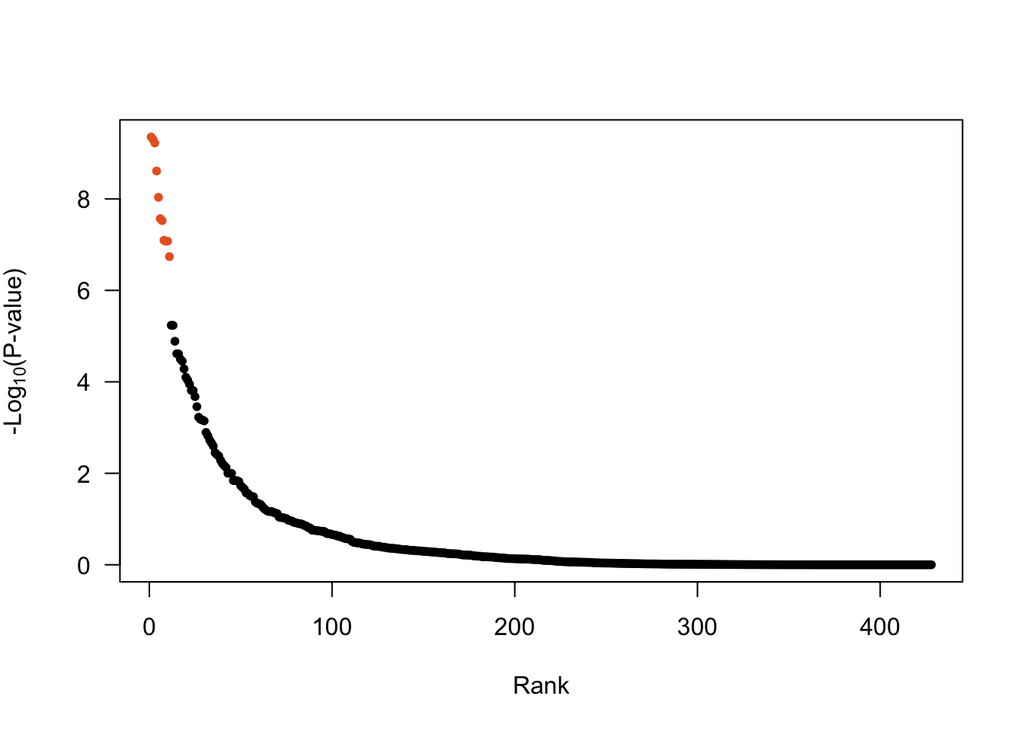

```r
log.p <- homer[[2]]$Log.P.value
log.p <- log.p * -1
index <- which(x = homer[[2]]$q.value <= 0.05)
name <- toupper(sapply(X = homer[[2]]$Motif[index], FUN = function(X) strsplit(x = X, split = "\\(")[[1]][1]))
ylab <- expression(paste("-Log"[10],"(P-value)"))
point.col <- rep("black",nrow(homer[[2]]))
point.col[which(homer[[2]]$q.value < 0.05)] <- r.config$simple.cols[3]
plot(x = 1:nrow(homer[[2]]), y = log.p, pch = 20, col = point.col, xlab = "Rank", ylab = ylab, las = 1)
```

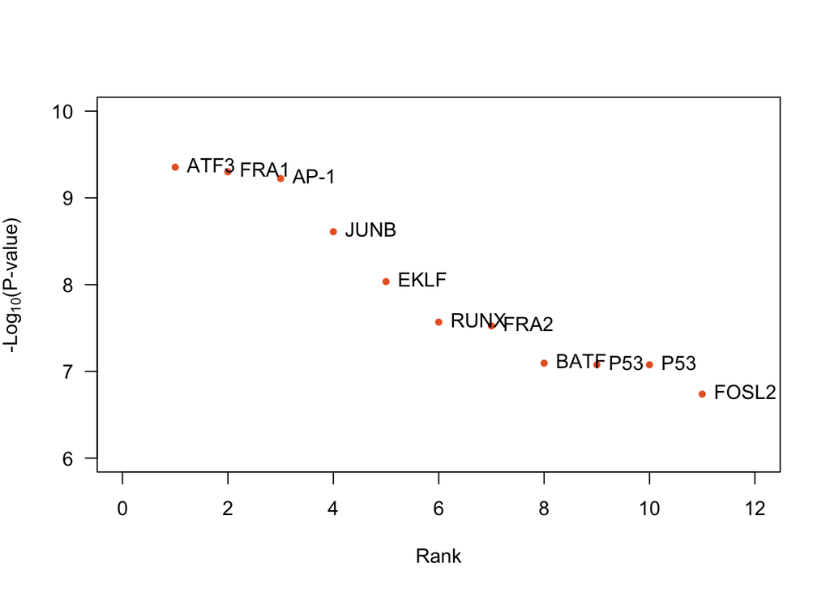

```r
plot(x = 1:nrow(homer[[2]]), y = log.p, pch = 20, col = point.col, xlab = "Rank", ylab = ylab, las = 1, ylim = c(6,10), xlim = c(0,12))
text(x = index, y = log.p[index], labels = name, adj = c(0,1), pos = 4)
```

```r
png.name <- file.path(r.config$dirs$figure.dir,"ATAC_03_homerRanks.png")
png(filename = png.name, width = 4.5, height = 4.5, units = r.config$fig.specs$units, res = r.config$fig.specs$res, pointsize = r.config$fig.specs$pointsize)
par(mar = c(4,4,1,1))
plot(x = 1:nrow(homer[[2]]), y = log.p, pch = 20, col = point.col, xlab = "Rank", ylab = ylab, las = 1)
# text(x = index, y = log.p[index], labels = name, adj = 0, pos = c(4,3))
dev.off()
```

```r
write_xlsx(x = homer, path = file.path(r.config$dirs$table.dir,"ATAC_SupplementaryTable_02.xlsx"), col_names = TRUE)
```